# Local Binary Patterns (LBP)

Aplication example:

- https://www.pyimagesearch.com/2015/12/07/local-binary-patterns-with-python-opencv/

```python
from skimage.feature import local_binary_pattern
import numpy as np
import matplotlib.pyplot as plt
import cv2
```

## Algorithm

The algorithm has two main parameters:

- Number of points, $p$.
- Circle radius (distance from the target pixel), $r$.

Next figure show the effect of those parameters, the images shows the points used using different $p$ and $r$ values.

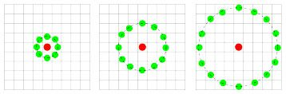

**scikit-image algorithm link:** https://scikit-image.org/docs/dev/auto_examples/features_detection/plot_local_binary_pattern.html

## Used images

```python
from glob import glob

images = glob("./*[.jpg|.jpeg]")
images
```

```
['.\\textura_1.jpg',
 '.\\textura_2.jpeg',
 '.\\textura_3.jpeg',
 '.\\textura_4.jpeg']
```

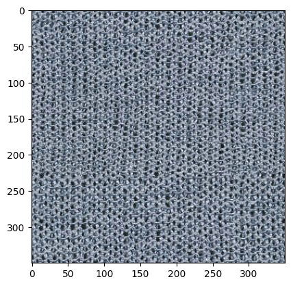

```python
for path_im in images:
    im = cv2.imread(path_im)
    plt.imshow(im)
```

## The algorithm

```python
from skimage.transform import rotate
from skimage.feature import local_binary_pattern
from skimage import data
from skimage.color import label2rgb
```

```python
def overlay_labels(image, lbp, labels):
    mask = np.logical_or.reduce([lbp == each for each in labels])
    return label2rgb(mask, image=image, bg_label=0, alpha=0.5)


def highlight_bars(bars, indexes):
    for i in indexes:
        bars[i].set_facecolor('r')


def hist(ax, lbp):
    n_bins = int(lbp.max() + 1)
    return ax.hist(lbp.ravel(), density=True, bins=n_bins, range=(0, n_bins),
                   facecolor='0.5')
```

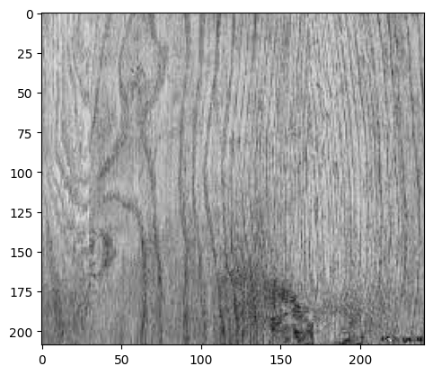

```python
image = cv2.imread("./textura_2.jpeg")
image = cv2.cvtColor(image, cv2.COLOR_BGR2GRAY)
plt.imshow(image, cmap="gray");
```

```python
radius = 3
n_points = 8 * radius

lbp = local_binary_pattern(image, n_points, radius, 'uniform')
```

```python
lbp.shape
```

```
(209, 241)
```

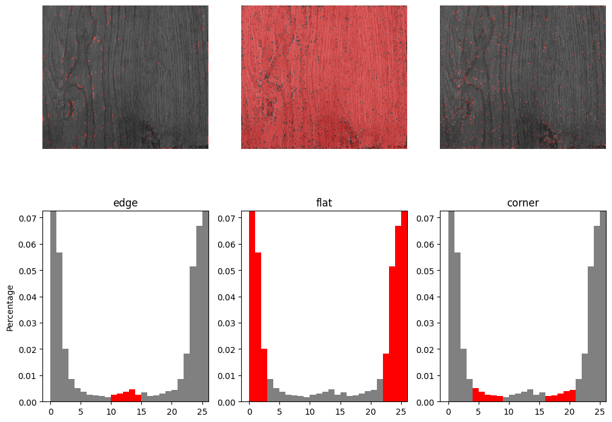

```python
# plot histograms of LBP of textures
fig, (ax_img, ax_hist) = plt.subplots(nrows=2, ncols=3, figsize=(12, 9))
plt.gray()

titles = ('edge', 'flat', 'corner')
w = width = radius - 1
edge_labels = range(n_points // 2 - w, n_points // 2 + w + 1)
flat_labels = list(range(0, w + 1)) + list(range(n_points - w, n_points + 2))
i_14 = n_points // 4            # 1/4th of the histogram
i_34 = 3 * (n_points // 4)      # 3/4th of the histogram
corner_labels = (list(range(i_14 - w, i_14 + w + 1)) +
                 list(range(i_34 - w, i_34 + w + 1)))

label_sets = (edge_labels, flat_labels, corner_labels)

for ax, labels in zip(ax_img, label_sets):
    ax.imshow(overlay_labels(image, lbp, labels))

for ax, labels, name in zip(ax_hist, label_sets, titles):
    counts, _, bars = hist(ax, lbp)
    highlight_bars(bars, labels)
    ax.set_ylim(top=np.max(counts[:-1]))
    ax.set_xlim(right=n_points + 2)
    ax.set_title(name)

ax_hist[0].set_ylabel('Percentage')
for ax in ax_img:
    ax.axis('off')
```

## Tasks

Using the images from the train and test folders, used respectively as train and test data, build an image classifier.

Each image class is specified in its file name. There are three classes: banded, braided i veined.

You can use a linear SVM.

Explain the results.

## Build a Classifier

```python
import cv2
import numpy as np
from skimage.feature import local_binary_pattern
from sklearn.svm import SVC
from sklearn.metrics import classification_report, accuracy_score, confusion_matrix
from glob import glob
import os
import seaborn as sns
import matplotlib.pyplot as plt
```

```python
"""
Extract LBP features from an image.
"""

def extract_features(image_path, radius=3):
    n_points = 8 * radius
    image = cv2.imread(image_path, cv2.IMREAD_GRAYSCALE) # Read in greyscale
    lbp = local_binary_pattern(image, n_points, radius, method="uniform")
    print(f'lbp shape: {lbp.shape}')
    (hist, _) = np.histogram(lbp.ravel(), bins=np.arange(0, n_points + 3), range=(0, n_points + 2))

    # Normalize the histogram
    hist = hist.astype("float")
    hist /= (hist.sum() + 1e-7)
    return hist
```

```python
def prepare_data(folder_path):
    features = []
    labels = []
    for img_path in glob(os.path.join(folder_path, "*.jpg")):
        label = os.path.basename(img_path).split('_')[0]
        print(f'Label of {img_path} is {label}')
        feature_vector = extract_features(img_path)
        features.append(feature_vector)
        labels.append(label)
    return np.array(features), np.array(labels)

# Paths --> training and testing folders
train_folder = 'train'
test_folder = 'test'

X_train, y_train = prepare_data(train_folder)
X_test, y_test = prepare_data(test_folder)
```

```
Label of train\banded_0083.jpg is banded
lbp shape: (480, 640)
Label of train\banded_0086.jpg is banded
lbp shape: (500, 500)
Label of train\banded_0089.jpg is banded
lbp shape: (512, 640)
Label of train\banded_0093.jpg is banded
lbp shape: (360, 640)
Label of train\banded_0096.jpg is banded
lbp shape: (316, 420)
Label of train\braided_0075.jpg is braided
lbp shape: (320, 480)
Label of train\braided_0106.jpg is braided
lbp shape: (450, 600)
Label of train\braided_0107.jpg is braided
lbp shape: (373, 322)
Label of train\braided_0141.jpg is braided
lbp shape: (480, 640)
Label of train\veined_0087.jpg is veined
lbp shape: (426, 639)
Label of train\veined_0088.jpg is veined
lbp shape: (426, 639)
Label of train\veined_0089.jpg is veined
lbp shape: (426, 639)
Label of train\veined_0090.jpg is veined
lbp shape: (426, 639)
Label of test\banded_0002.jpg is banded
lbp shape: (300, 300)
Label of test\banded_0137.jpg is banded
lbp shape: (587, 624)
Label of test\braided_0187.jpg is braided
lbp shape: (300, 478)
Label of test\veined_0086.jpg is veined
lbp shape: (426, 639)
```

```python
svm = SVC(kernel='linear')
svm.fit(X_train, y_train)
```

```
SVC(kernel='linear')
```

# Results explanation:

```
Confusion Matrix:
```

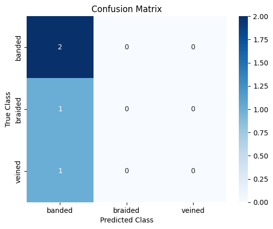

```
Accuracy: 0.5
```

```python
predictions = svm.predict(X_test)
conf_mat = confusion_matrix(y_test, predictions)

# Print de confusion matrix
print("Confusion Matrix:")
sns.heatmap(conf_mat, annot=True, fmt='g', cmap='Blues', xticklabels=svm.classes_, yticklabels=svm.classes_)
plt.title('Confusion Matrix')
plt.ylabel('True Class')
plt.xlabel('Predicted Class')
plt.show()

print('Accuracy:', accuracy_score(y_test, predictions))
```

The confusion matrix you have provided shows that the SVM classifier you have trained has predicted all test instances as belonging to the 'banded' class. Here is a breakdown of what the confusion matrix reveals the next:

- True Positives (TP): The classifier has correctly predicted 2 instances of the 'banded' class.
- False Negatives (FN): The classifier has failed to correctly predict any instances of the 'braided' and 'veined' classes. Instead, it has misclassified these instances as 'banded'. This is indicated in the first column where there should have been 0 for 'banded', but instead there is 1 for 'braided' and 1 for 'veined'.

Moreover, the accuracy of 0.5 means that, out of all test instances, only 50% were classified correctly. In this case, 2 out of 4 instances were classified correctly as 'banded', and the other 2 were misclassifications of the other classes.

### Why this is happening?

The training set contains more instances of the 'banded' class compared to 'braided' and 'veined', which may cause the classifier to be biased towards predicting 'banded' due to an imbalanced training data. Moreover, the small training set size could lead to the model overfitting to the 'banded' class, which was the majority in training. But, what can metrics say?

```python
print(classification_report(y_test, predictions, zero_division=0))
```

```
              precision    recall  f1-score   support

      banded       0.50      1.00      0.67         2
     braided       0.00      0.00      0.00         1
      veined       0.00      0.00      0.00         1

    accuracy                           0.50         4
   macro avg       0.17      0.33      0.22         4
weighted avg       0.25      0.50      0.33         4
```

As it can see, a classification report about our classifier is not a helpfull idea, their significance is limited due to several factors as the small dataset, where only 4 images are in the test set, each instance heavily influences the overall metrics. Moreover, te lack of predictive power for minority classes, the precision and recall for 'braided' and 'veined' are 0, indicating the model failed to predict any instances of these classes correctly, due to the model has not learned features that are discriminative for these classes.